# Heated Rivalry

Jacob Noble

# Daniel B. Carr

In college I studied under a great man named Daniel B. Carr. He taught me how to use R, R Studio, and a library called micromapST.

```r
library(micromapST)
# other important libraries
library(httr)
library(jsonlite)
library(dplyr)
library(reshape2)
```

This library enables the use of Linked Micromaps within R visualizations. These are maps containing regional delineation, such as a map of the United States with state boundaries. A set of maps can be added to a side panel attached to a data display, such that the data is visually mapped to a location.

# Heated Rivalry

My wife enjoys a show called “Heated Rivalry”. I have not seen it, but I know it has to do with Hockey. My son has been learning to play Hockey, so I have been looking for opportunities to engage with the sport. Living in Texas, we use our Ice Skating outings as an opportunity to escape the heat. This got me thinking- is there any correlation between NHL team performance and the average temperature of the city they come from? In this post I will explore this question using R and the micromapST library.

# Data Collection

When looking for NHL season data, there are a few options: - The NHL API, which is a RESTful API that provides access to NHL data in JSON format. - The NHL Stats website, which provides access to NHL data in HTML format. - Unofficial data aggregation sites, such as Kaggle.

I first looked at the API, as documented by Zmalski on his [NHL API GitHub page](https://github.com/Zmalski/NHL-API-Reference). Some of these endpoints work better than others, but overall this is a viable source. That being said, are there any datasets available on Kaggle that I can grab-and-go?

- No.
  - There are some good collections, but nothing aligns with my exact needs. I would have to do some data wrangling across multiple datasets to get what I want. This is not a deal breaker, but it begs the question “why not use the API?”

What about the stats website?

- No.
  - The data is there, but it is not easily accessible. I would have to scrape the data from the HTML pages, which is typically harder than using the API.

Which brings us back to the API.

## Exploring the NHL API

We will likely use 2 or 3 different API calls to pull all the data we need. Before we get into that, let’s pull down basic team data so we can demo the micromapST library.

- NHL API Endpoint for all games since 1917: https://api.nhle.com/stats/rest/en/game

To query the endpoint, we will need to use the `httr` and `jsonlite` libraries.  
The `httr` library is used to make GET requests to the API, and the `jsonlite` library is used to parse the JSON response into a data frame.

> NOTE: typically we should use httr2, which allows us to construct and send requests as two separate steps. This is crucial for diagnosing issues with the request, as we can inspect the request before sending it.

> In this case, we will use httr, which is a simpler library that combines the request construction and sending into a single step. The NHL API requires no authorization, and no special headers, so we can get away with using httr.

```r
library(httr)
library(jsonlite)
```

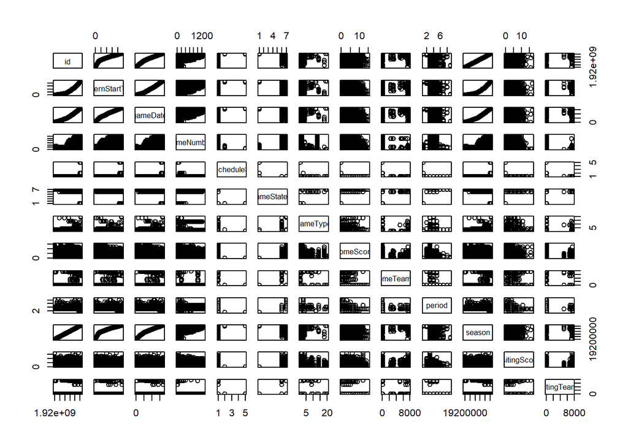

```r
response <- GET("https://api.nhle.com/stats/rest/en/game")

# This converts http errors into R errors, which is useful for debugging.
stop_for_status(response)
# Process response into table
data_raw <- fromJSON(content(response, "text", encoding = "UTF-8"))
# Convert to data frame
game_df <- as.data.frame(data_raw$data)

plot(game_df)
```

This plot is useless, but it shows that we have successfully pulled data from the API and converted it into a data frame. There is one major issue with this data set- it does not contain State Names for each team.

To get State Names, we can try another endpoint:

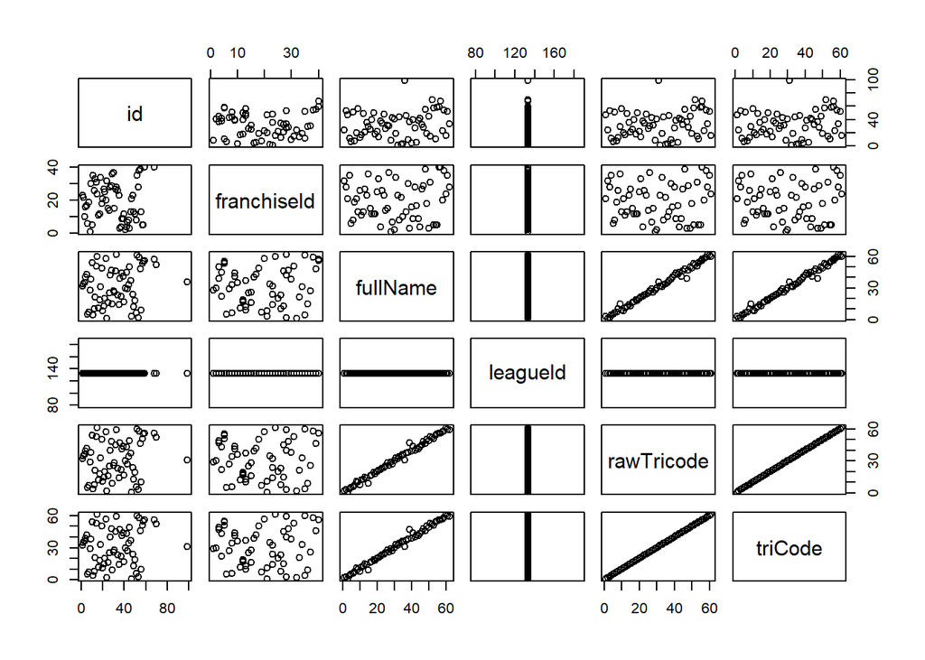

```r
response <- GET("https://api.nhle.com/stats/rest/en/team")

# This converts http errors into R errors, which is useful for debugging.
stop_for_status(response)

data_raw <- fromJSON(content(response, "text", encoding = "UTF-8"))
team_df <- as.data.frame(data_raw$data)

plot(team_df)
```

We still don’t have state name, but we have the TRI code. This is almost as good, and can be mapped to a state.

While we are looking at this data, let’s check the range of ID’s across the two data frames.

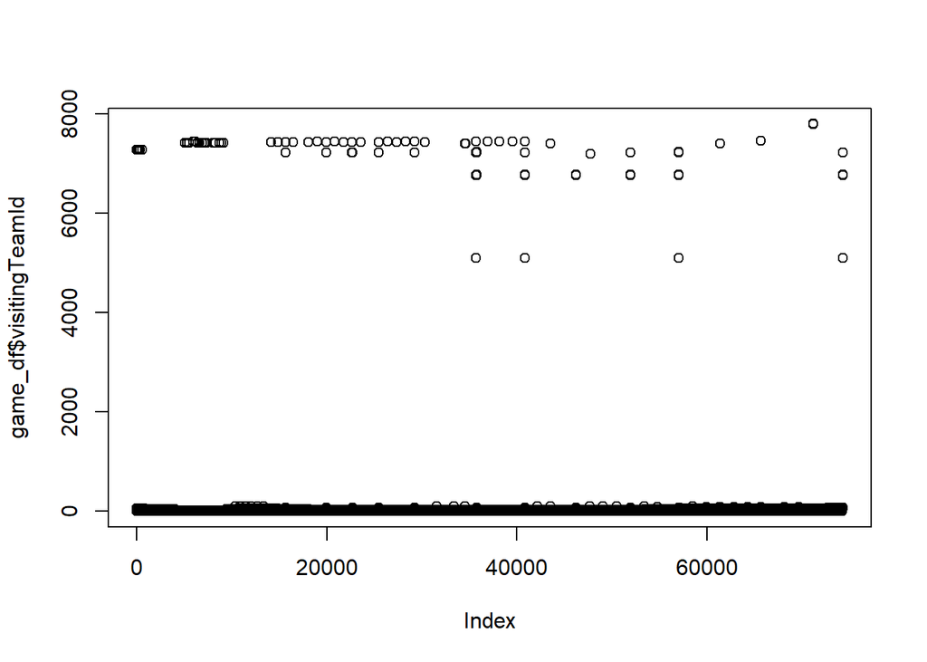

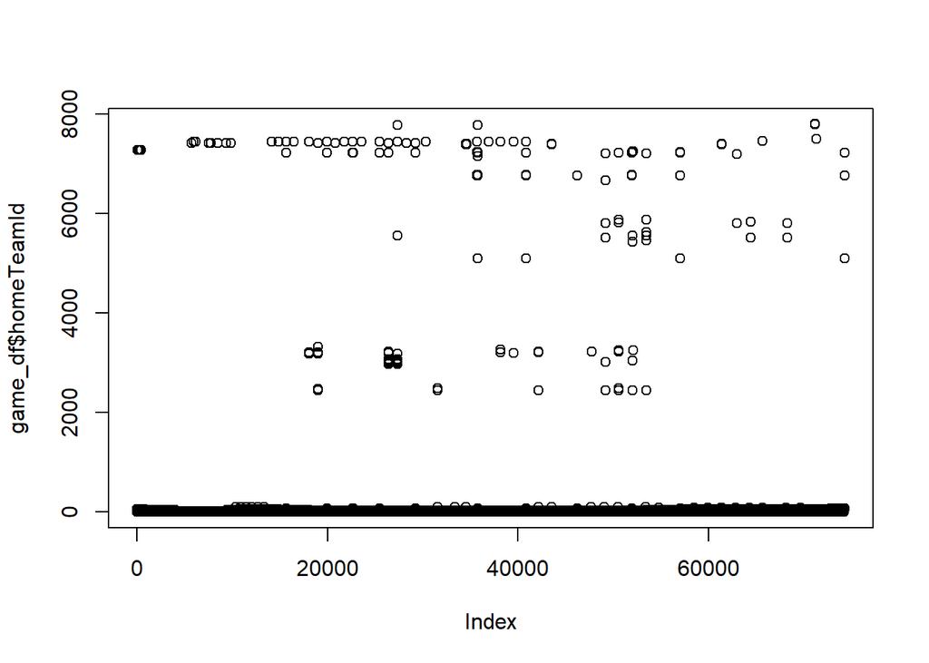

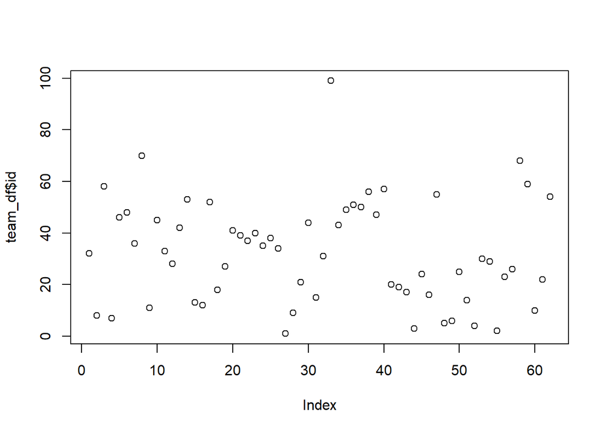

```r
# select distinct id from game_df
plot(game_df$visitingTeamId)
plot(game_df$homeTeamId)
plot(team_df$id)
```

Immediately we can see an issue. The range of ID’s is very different across the two data frames, and some values are missing from one or the other. This is likely due to the fact that the game data contains historical data, while the team data only contains current teams.

## NHL API: Top Scorer per State

In addition to the issues seen in the previous section, we also need to consider that some states have multiple teams, while others have none. This makes it difficult to compare team performance across states. To mitigate this, we will look at the top player per state, and use their performance as a proxy for team performance.

> NOTE: TRI Code to State mapping was generated via CoPilot

```r
response <- GET("https://api-web.nhle.com/v1/skater-stats-leaders/20182019/2?categories=points&limit=-1")

# This converts http errors into R errors, which is useful for debugging.
stop_for_status(response)
# Process response into table
data_raw <- fromJSON(content(response, "text", encoding = "UTF-8"))
# Convert to data frame
game_df <- as.data.frame(data_raw)

# read team-to-state mapping CSV
t2s <- read.csv("C:/Users/jaken/Downloads/team-code-to-state-code.csv")
# Inner join game_df with t2s on teamAbbrev and TRICODE
# Inner join b/c we only want USA teams
game_df <- game_df %>% inner_join(t2s, by = c("points.teamAbbrev" = "TRICODE"))

# Filter data to only top scorer from each state
game_df <- game_df %>% group_by(STATE) %>% slice_max(n = 1, order_by = points.value)

head(game_df)
```

| points.id | points.firstName | points.lastName | points.sweaterNumber | points.headshot | points.teamAbbrev | points.teamName | points.teamLogo | points.position | points.value | STATE |
| --- | --- | --- | --- | --- | --- | --- | --- | --- | --- | --- |
| 8479343 |  |  | 9 | https://assets.nhle.com/mugs/nhl/20182019/ARI/8479343.png | ARI |  | https://assets.nhle.com/logos/nhl/svg/ARI_20142015-20202021_light.svg | R | 47 | AZ |
| 8470613 |  |  | 84 | https://assets.nhle.com/mugs/nhl/20182019/SJS/8470613.png | SJS |  | https://assets.nhle.com/logos/nhl/svg/SJS_20082009-20232024_light.svg | D | 83 | CA |
| 8477492 |  |  | 29 | https://assets.nhle.com/mugs/nhl/20182019/COL/8477492.png | COL |  | https://assets.nhle.com/logos/nhl/svg/COL_light.svg | C | 99 | CO |
| 8471214 |  |  | 8 | https://assets.nhle.com/mugs/nhl/20182019/WSH/8471214.png | WSH |  | https://assets.nhle.com/logos/nhl/svg/WSH_light.svg | L | 89 | DC |
| 8476453 |  |  | 86 | https://assets.nhle.com/mugs/nhl/20182019/TBL/8476453.png | TBL |  | https://assets.nhle.com/logos/nhl/svg/TBL_light.svg | R | 128 | FL |
| 8474141 |  |  | 88 | https://assets.nhle.com/mugs/nhl/20182019/CHI/8474141.png | CHI |  | https://assets.nhle.com/logos/nhl/svg/CHI_19981999-20242025_light.svg | R | 110 | IL |

assign state names to rownames for player data

```r
game_df_rn <- data.frame(game_df %>% select(STATE, points.value, points.firstName, points.lastName))
game_df_rn$points.firstName <- game_df_rn$points.firstName[[1]]
game_df_rn$points.lastName <- game_df_rn$points.lastName[[1]]
game_df_rn$fullName <- paste(game_df_rn$points.firstName, game_df_rn$points.lastName)
rownames(game_df_rn) <- game_df_rn$STATE
game_df_rn <- game_df_rn %>% select(-STATE, -points.firstName, -points.lastName)
head(game_df_rn)
```

|  | points.value | fullName |
| --- | --- | --- |
| AZ | 47 | Clayton Keller |
| CA | 83 | Brent Burns |
| CO | 99 | Nathan MacKinnon |
| DC | 89 | Alex Ovechkin |
| FL | 128 | Nikita Kucherov |
| IL | 110 | Patrick Kane |

We now have the top scoring players from each state.

Next, we can join this with temperature data by state.

# Temperature by State

Temperature data can be sourced manually from the [NOAA Climate Data Online](https://www.ncdc.noaa.gov/cdo-web/datasets) website.

For this project, we will use a pre-compiled dataset available from Kaggle.com: [Temperature Over Time by State (Starts: 1894)](https://www.kaggle.com/datasets/thedevastator/analyzing-u-s-warming-rates-insights-into-climat?resource=download&select=climdiv_state_year.csv)

```r
temps_by_state <- read.csv("C:/Users/jaken/Downloads/climdiv_state_year.csv")
# States are represented by Federal Information Processing System (FIPS) code.
# Need to map these to state names.
fips_to_state <- read.csv("C:/Users/jaken/Downloads/fips2state.csv")

# combine
temps_by_state <- temps_by_state %>% left_join(fips_to_state, by = c("fips" = "FIPS"))

# convert state names to abbreviations
temps_by_state$name <- state.abb[match(tolower(temps_by_state$name), tolower(state.name))]

# grab most recent temps for a separate visual
most_recent_temps <- temps_by_state %>% filter(year == max(year)) %>% select(name, temp)

temps_by_state <- temps_by_state %>% select(name, year, temp)

temps_by_state$temp <- as.double(temps_by_state$temp)

head(temps_by_state)
```

|  | name | year | temp |
| --- | --- | --- | --- |
| 1 | AL | 1895 | 61.64167 |
| 2 | AL | 1896 | 64.26667 |
| 3 | AL | 1897 | 64.19167 |
| 4 | AL | 1898 | 62.98333 |
| 5 | AL | 1899 | 63.10000 |
| 6 | AL | 1900 | 63.40833 |

Filter state list to only include states that have NHL teams

```r
temps_by_state <- temps_by_state %>% filter(name %in% game_df$STATE)
```

Limit to 2000-2019

```r
temps_by_state <- temps_by_state %>% filter(year >= 2000 & year <= 2019)
```

Format for micromaps

```r
# Micromaps time series requires the dataset to be a 3D array
# Rows are states, columns are periods, first dimension is year, second dimension is temperature.
library(reshape2)
temps_by_state <- temps_by_state %>%
  arrange(name, year) %>%
  group_by(name) %>%
  mutate(period = row_number()) %>%
  ungroup()
matrix_year <- acast(temps_by_state, name ~ period, value.var = "year")
matrix_temp <- acast(temps_by_state, name ~ period, value.var = "temp")

temps_3d <- array(
  c(matrix_year, matrix_temp),
  dim = c(nrow(matrix_year), ncol(matrix_year), 2),
  dimnames = list(rownames(matrix_year), colnames(matrix_year), c("x","y"))
)

temprate <- data.frame(temps = temps_3d[ , , 2])
avg_temps <- mean(temprate[,ncol(temprate)], na.rm = TRUE)
head(temps_3d[,1,])
```

```
##       x        y
## AZ 2000 61.67500
## CA 2000 58.80000
## CO 2000 47.00000
## FL 2000 70.57500
## IL 2000 52.20000
## MA 2000 47.51667
```

Add player data to temprate

```r
temprate <- cbind(temprate, game_df_rn[rownames(temprate),])
```

Now that we have temps by state, we can create a time series graph.

We will also capture the average temperature for the most recent year of data (2019), as well as the points scored by the top scorer from each state for the season (2118-2019).

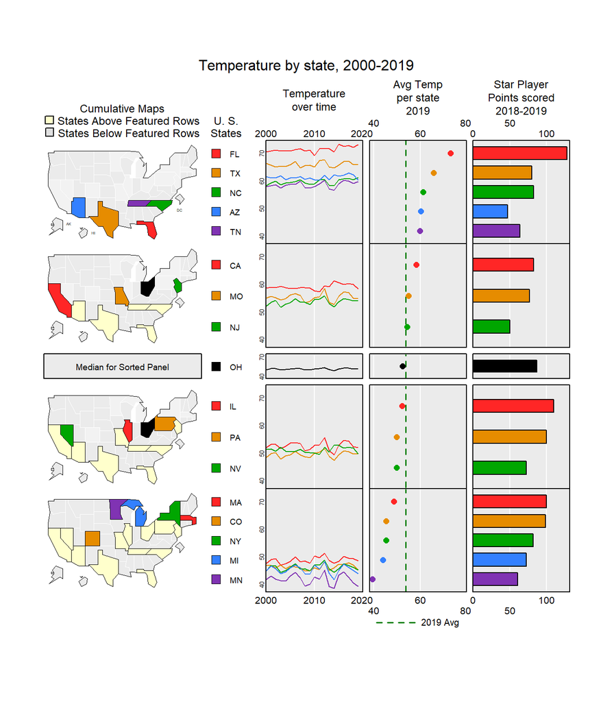

```r
panelDesc01 <- data.frame(
  type=c("mapcum","id","ts","dot","bar"),
  lab1=c("","","Temperature\nover time\n","Avg Temp\nper state\n2019","Star Player\nPoints scored\n2018-2019"),
  col1=c(NA,NA,2,20,21),
  #col2=c(NA,NA,2),
  refVals=c(NA,NA,NA,avg_temps, NA),
  refTexts=c(NA,NA, NA,"2019 Avg", NA),
  panelData= c("","","temps_3d","", "game_df_rn")
  )

micromapST(temprate, panelDesc01, sortVar=20, ascend=FALSE, rowNames="ab",
               title=c("Temperature by state, 2000-2019"),
           ignoreNoMatches = TRUE
           )
```

Now we can begin to visualize the relationship between temperature and top player performance by state.

As expected, there is no obvious correlation. Player training conditions are similar across climates as they train indoors.

To further analyze this, we can modify our micromap code to use points-scored as the sorting variable.

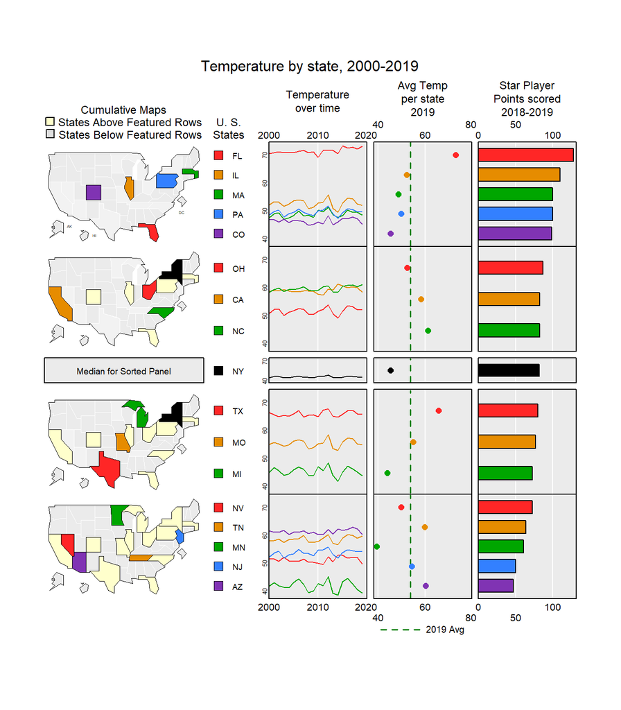

```r
panelDesc01 <- data.frame(
  type=c("mapcum","id","ts","dot","bar"),
  lab1=c("","","Temperature\nover time\n","Avg Temp\nper state\n2019","Star Player\nPoints scored\n2018-2019"),
  col1=c(NA,NA,2,20,21),
  #col2=c(NA,NA,2),
  refVals=c(NA,NA,NA,avg_temps, NA),
  refTexts=c(NA,NA, NA,"2019 Avg", NA),
  panelData= c("","","temps_3d","", "game_df_rn")
  )

micromapST(temprate, panelDesc01, sortVar=21, ascend=FALSE, rowNames="ab",
               title=c("Temperature by state, 2000-2019"),
           ignoreNoMatches = TRUE
           )
```

# Conclusion

There is no correlation between average temperature and star player performance.

We knew this going into the project, but I wanted an excuse to show off linked micromaps.

If you would like to explore micromaps on your own, please [Professor Carr’s GMU Faculty webpage](https://mason.gmu.edu/~dcarr/) where he provides example files for download.